# HW2

```python
import torch
import numpy as np
import pandas as pd
import matplotlib as mpl
import matplotlib.pyplot as plt
import matplotlib.gridspec as gridspec
from scipy.stats import chi2
from scipy.stats import chisquare
from scipy.stats import binom
from scipy.stats import beta
from scipy.stats import gamma
from scipy.stats import norm
from scipy.stats import invgamma


import statistics as stat

%matplotlib inline

mpl.rcParams['pdf.fonttype'] = 42
mpl.rcParams['ps.fonttype'] = 42
fig_dpi      = 300
fig_typeface = 'Helvetica'
fig_family   = 'monospace'
fig_style    = 'normal'
```

## 1.a

Sample X, Y from N(0,1).

```python
class Drunkman(object):
    def __init__(self, start_point:list = [0,0], steps:int = 50):
        self.start_point = start_point
        self.steps = steps
    def __repr__(self):
        return "I am a drunk man."
    def walk(self, start_point = [0,0]):
        self.start_point = start_point
        oneTrack = [self.start_point]
        for i in range(self.steps):
            x = np.random.normal(0,1)
            y = np.random.normal(0,1)
            self.start_point = [self.start_point[0] + x,  self.start_point[1] +y]
            oneTrack.append(self.start_point)
        return oneTrack
    def getLocation(self):
        # Use one hot to show the final position
        location = np.array([0,0,0,0], dtype = "float64")
        oneTrack = self.walk()
        if oneTrack[-1][0] >= 0:
            if oneTrack[-1][1] > 0:
                location[0] += 1
        if oneTrack[-1][0] <= 0:
            if oneTrack[-1][1] < 0:
                location[2] += 1
        if oneTrack[-1][0] > 0:
            if oneTrack[-1][1] <= 0:
                location[3] += 1
        if oneTrack[-1][0] < 0:
            if oneTrack[-1][1] >= 0:
                location[1] += 1
        return location

    def oneTrack_plot(self):
        oneTrack  = self.walk()
        track = np.array(oneTrack)
        X = track[:, 0]
        Y = track[:, 1]
        x_range = [-np.max(np.abs(X)), np.max(np.abs(X))]
        y_range = [-np.max(np.abs(Y)), np.max(np.abs(Y))]
        f, ax = plt.subplots(1, 1, figsize=(3, 3), facecolor='white', dpi=300, gridspec_kw={'hspace': 0., 'wspace': 0.})
        ax.plot(0, 0, ".",3, c = "blue", zorder = 1)
        ax.plot(X[-1], Y[-1], ".",3, c = "darkgreen", zorder = 1)
        ax.plot(X, Y, "-",1., c = "darkred", zorder = 0)
        ax.tick_params(axis='both', which='both', labelsize='xx-small', right=True, top=True, direction='in', width=.4)

        ax.vlines(0,y_range[0], y_range[1], ls = '--', color = 'black',lw = .5)
        ax.hlines(0,x_range[0], x_range[1], ls = '--', color = 'black',lw = .5)

        ax.set_xlabel("X", size='x-small')
        ax.set_ylabel("Y", size='x-small')
        ax.set_xlim(x_range)
        ax.set_ylim(y_range)
#         ax.legend(loc = 1 ,fontsize = 3,markerscale = 2,ncol = 3,scatterpoints= 1,frameon = True,framealpha =0.).get_frame().set_linewidth(0.0)
        plt.show()

    def Trials(self, manNum : int = 10000):
        initial = np.array([0,0,0,0], dtype = "float64")
        for _ in range(manNum):
            finalLocation = self.getLocation()
            initial += finalLocation
        return initial
```

```python
Walk_man = Drunkman()
```

### 1.a.(1) Plot 1 random walk. of 50. steps

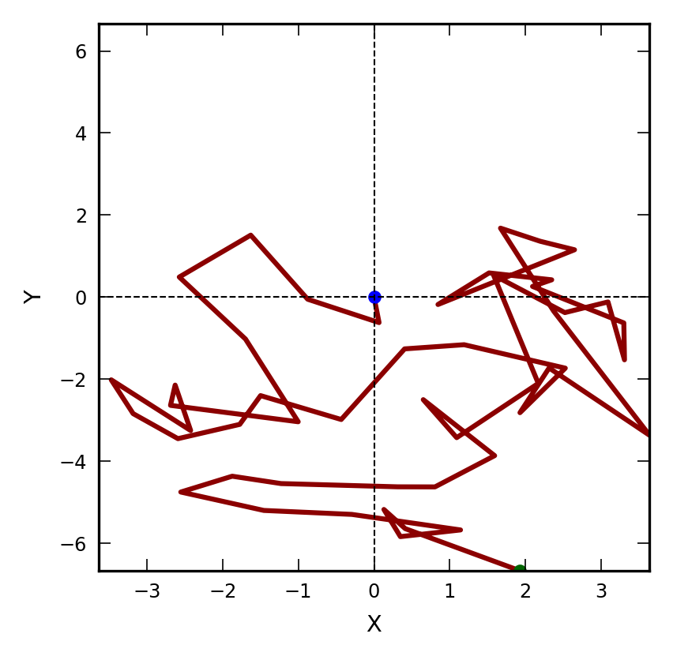

```python
Walk_man.oneTrack_plot()
```

### 1.a.(2) Report the number that ends in each quadrant

```python
num_counts = Walk_man.Trials()
num_counts
```

```
array([2557., 2398., 2509., 2536.])
```

### 1.a.(3) What values would you expect for these proportions? Do the observed proportions vary significantly from the expected values?

I think $p_1 = p_2 = p_3 = p_4 = \frac{1}{4}$.  
And I plan to do Chi-square test using the results showed above.  
$H_0: $ $p_1 = p_2 = p_3 = p_4 = \frac{1}{4}$.  
$H_a: $ It's not the case and they are not equal to each other. Then the test Statistic $\sum_{i=1}^{i=4}\frac{\frac{f_i}{N} - \frac{1}{4} }{1/4}$ follows $\chi^2(3)$

```python
H_null = np.array([1/4, 1/4, 1/4, 1/4])
chisq, p = chisquare(num_counts/np.sum(num_counts), f_exp=H_null, ddof=0)
print(f"The p-value is {p:4.5f}, so we accept the null hypothesis.")
```

```
The p-value is 1.00000, so we accept the null hypothesis.
```

## 1.b (steps goes to 500)

```python
Walk_man500 = Drunkman(steps = 500)
```

### 1.b.(1) Report the number that ends in each quadrant

```python
num_counts500 = Walk_man500.Trials()
num_counts500
```

```
array([2543., 2461., 2459., 2537.])
```

### 1.b.(3) What values would you expect for these proportions? Do the observed proportions vary significantly from the expected values?

I think $p_1 = p_2 = p_3 = p_4 = \frac{1}{4}$.  
And I plan to do Chi-square test using the results showed above.  
$H_0: $ $p_1 = p_2 = p_3 = p_4 = \frac{1}{4}$.  
$H_a: $ It's not the case and they are not equal to each other. Then the test Statistic $\sum_{i=1}^{i=4}\frac{\frac{f_i}{N} - \frac{1}{4} }{1/4}$ follows $\chi^2(3)$

```python
H_null = np.array([1/4, 1/4, 1/4, 1/4])
chisq, p = chisquare(num_counts500/np.sum(num_counts500), f_exp=H_null, ddof=0)
print(f"The p-value is {p:4.5f}, so we accept the null hypothesis.")
```

```
The p-value is 1.00000, so we accept the null hypothesis.
```

### 1.Repeat 1a and 1b using random walks on the lattice in $R^2$

```python
class DrunkmanOnLattice1(Drunkman):
    def __init__(self, start_point:list = [0,0], steps:int = 50):
        super(Drunkman,self).__init__()
        self.steps = steps
        self.start_point = start_point

    def walk(self, start_point = [0,0]):
        step_choice = [[1,0], [1,1],[0,1],[-1,1], [-1,0], [-1,-1],[0,-1],[1,-1]]
        self.start_point = start_point
        oneTrack = [self.start_point]
        for i in range(self.steps):
            step = step_choice[np.random.randint(0,8)]
            self.start_point = [self.start_point[0] + step[0],  self.start_point[1] + step[1]]
            oneTrack.append(self.start_point)
        return oneTrack
```

```python
class DrunkmanOnLattice2(Drunkman):
    def __init__(self, start_point:list = [0,0], steps:int = 50):
        super(Drunkman,self).__init__()
        self.steps = steps
        self.start_point = start_point

    def walk(self, start_point = [0,0]):
        step_choice = [[1,0],[0,1], [-1,0],[0,-1]]
        self.start_point = start_point
        oneTrack = [self.start_point]
        for i in range(self.steps):
            step = step_choice[np.random.randint(0,4)]
            self.start_point = [self.start_point[0] + step[0],  self.start_point[1] + step[1]]
            oneTrack.append(self.start_point)
        return oneTrack
```

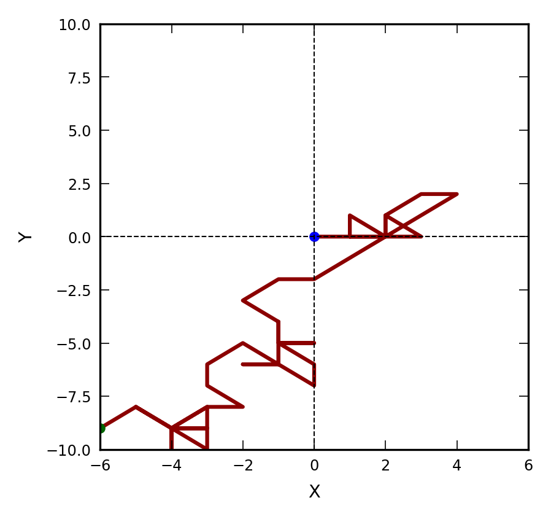

```
array([2519., 2525., 2399., 2511.])
```

```python
# He can walk along the diagonals.
Walk_manL1 = DrunkmanOnLattice1()
Walk_manL1.oneTrack_plot()
numL_counts = Walk_manL1.Trials()
numL_counts
```

I think $p_1 = p_2 = p_3 = p_4 = \frac{1}{4}$.  
And I plan to do Chi-square test using the results showed above.  
$H_0: $ $p_1 = p_2 = p_3 = p_4 = \frac{1}{4}$.  
$H_a: $ It's not the case and they are not equal to each other. Then the test Statistic $\sum_{i=1}^{i=4}\frac{\frac{f_i}{N} - \frac{1}{4} }{1/4}$ follows $\chi^2(3)$

```python
H_null = np.array([1/4, 1/4, 1/4, 1/4])
chisq, p = chisquare(num_counts500/np.sum(num_counts500), f_exp=H_null, ddof=0)
print(f"The p-value is {p:4.5f}, so we accept the null hypothesis.")
```

```
The p-value is 1.00000, so we accept the null hypothesis.
```

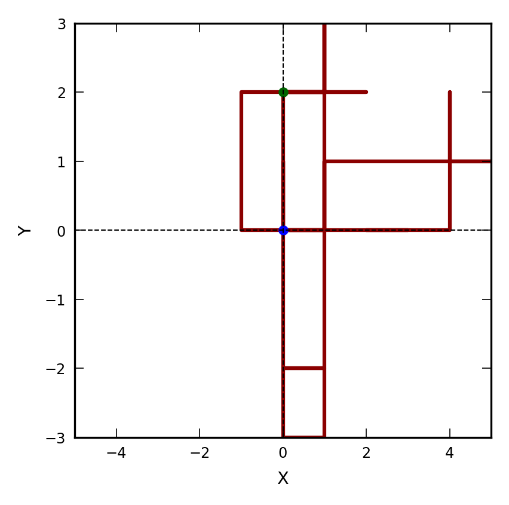

```
array([2436., 2475., 2491., 2474.])
```

```python
# He can just walk along the grids.
Walk_manL2 = DrunkmanOnLattice2()
Walk_manL2.oneTrack_plot()
numL_counts = Walk_manL2.Trials()
numL_counts
```

```python
H_null = np.array([1/4, 1/4, 1/4, 1/4])
chisq, p = chisquare(num_counts500/np.sum(num_counts500), f_exp=H_null, ddof=0)
print(f"The p-value is {p:4.5f}, so we accept the null hypothesis.")
```

```
The p-value is 1.00000, so we accept the null hypothesis.
```

As for the 500 steps, it is the same but with the initial DrunkmanOnLattice(500). They have the same conclusion for the $\chi^2$ test

## 2. Sample from Binomial(14,9); Beta(5,5); Gamma(12,2); IG(12,2); $\chi^2(2)$; $\chi^{-2}(2)$

```python
pointNums = [1e2,1e4, 1e5, 1e6, 1e7]
```

```python
table1E4 = pd.DataFrame()
Distributions = ["Binomial", "Beta", "Gamma","InverseGamma", "ChiSquare","InverseChiSquare"]
for pointNum in pointNums:
    BinPoints = np.random.binomial(14, .9, int(pointNum))
    BetaPoints = np.random.beta(.5, .5, int(pointNum))
    GammaPoints = np.random.gamma(12, 1/2, int(pointNum)) # Here I use 1/beta, cuz python uses the alternative form.
    IGPoints = 1/np.random.gamma(12, 1/2, int(pointNum)) # 1/X ~ Gamma(12,2); then X ~ IG(12,2)
    ChiPoints = np.random.chisquare(2, int(pointNum))
    IChiPoints = 1/np.random.chisquare(2, int(pointNum))# 1/X ~ ChiSq(2); then X ~ IChiSq(2)
#     IChiPoints = 1/np.random.gamma(1,1/2, int(pointNum))
    table = pd.DataFrame({"Binomial": BinPoints, "Beta":BetaPoints, "Gamma":GammaPoints,
                         "InverseGamma": IGPoints, "ChiSquare":ChiPoints, "InverseChiSquare":IChiPoints})
    exec("Table%s = table"%str(int(pointNum)))
    print("Table%s created"%str(int(pointNum)))
```

```
Table100 created
Table10000 created
Table100000 created
Table1000000 created
Table10000000 created
```

```python
2/11/11/5
```

```
0.003305785123966942
```

```python
STDs = []
EPs = []
for pointNum in pointNums:
    exec("table = Table%s"%str(int(pointNum)))
    std = []
    ep = []
    for col in table.columns:
        std.append(np.std(table[col]))
        ep.append(np.mean(table[col]))
    STDs.append(std)
    EPs.append(ep)
STDs = np.array(STDs)
EPs = np.array(EPs)
```

```python
STD_tabel = pd.DataFrame(STDs,columns = Distributions)
STD_tabel.index = pd.Series(["1e2","1e4", "1e5", "1e6", "1e7"])
EP_tabel = pd.DataFrame(EPs,columns = Distributions)
EP_tabel.index = pd.Series(["1e2","1e4", "1e5", "1e6", "1e7"])
```

```python
STD_tabel
```

|  | Binomial | Beta | Gamma | InverseGamma | ChiSquare | InverseChiSquare |
| --- | --- | --- | --- | --- | --- | --- |
| 1e2 | 1.068597 | 0.347124 | 1.685416 | 0.063718 | 1.786718 | 16.519434 |
| 1e4 | 1.115702 | 0.354414 | 1.736821 | 0.057843 | 2.006398 | 241.289256 |
| 1e5 | 1.120014 | 0.354066 | 1.734220 | 0.057736 | 2.003261 | 284.759514 |
| 1e6 | 1.121812 | 0.353827 | 1.732433 | 0.057495 | 2.002551 | 1904.222821 |
| 1e7 | 1.122769 | 0.353615 | 1.732307 | 0.057521 | 2.000062 | 5270.254600 |

```python
EP_tabel
```

|  | Binomial | Beta | Gamma | InverseGamma | ChiSquare | InverseChiSquare |
| --- | --- | --- | --- | --- | --- | --- |
| 1e2 | 12.590000 | 0.463507 | 5.681483 | 0.186208 | 1.633425 | 8.113601 |
| 1e4 | 12.597000 | 0.495860 | 6.012049 | 0.182295 | 1.997652 | 18.958098 |
| 1e5 | 12.597200 | 0.501169 | 5.995845 | 0.181720 | 1.999858 | 18.603301 |
| 1e6 | 12.601645 | 0.499771 | 6.000658 | 0.181763 | 2.001047 | 24.873609 |
| 1e7 | 12.599799 | 0.500024 | 6.000174 | 0.181820 | 2.000061 | 29.114923 |

The true values of expectation and variance are shown below in the table according to the formulas. The simulation results approximate the real values

[output not shown]

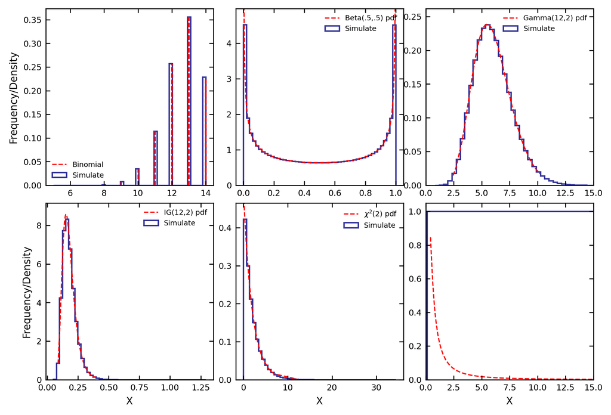

```python
f,ax = plt.subplots(figsize=(6.5, 4.8), dpi=300)
gs1 = gridspec.GridSpec(2, 1)
gs1.update(left=0.01, right=0.31, bottom=0.05, top=0.95, hspace=0.1, wspace=0.)
ax1 = plt.subplot(gs1[0])
ax4 = plt.subplot(gs1[1])


gs2 = gridspec.GridSpec(2, 1)
gs2.update(left=0.35, right=0.65, bottom=0.05, top=0.95, hspace=0.1, wspace=0.)
ax2 = plt.subplot(gs2[0])
ax5= plt.subplot(gs2[1])


gs3 = gridspec.GridSpec(2, 1)
gs3.update(left=0.69, right=0.99, bottom=0.05, top=0.95, hspace=0.1, wspace=0.)
ax3 = plt.subplot(gs3[0])
ax6 = plt.subplot(gs3[1])

table = Table10000000
# x1 = np.arange(binom.ppf(0.0, 14, .9),
#               binom.ppf(1.0, 14, .9))
for i in range(len(Distributions)):
    col = Distributions[i]
    data = np.array(Table100[col])
    data.sort()
    exec("x%d = data"%(i+1))
ax1.vlines(x1, 0, binom.pmf(x1, 14, .9), colors='red', linestyles='--', lw=1, label = "Binomial", zorder = 1)
ax2.plot(x2, beta.pdf(x2, .5, .5), 'r--', lw=1, label='Beta(.5,.5) pdf', zorder = 1)
ax3.plot(x3, gamma.pdf(x3, 12,0, 1/2), 'r--', lw=1, label='Gamma(12,2) pdf', zorder = 1)
ax4.plot(x4, invgamma.pdf(x4, 12,0, 2), 'r--', lw=1, label='IG(12,2) pdf', zorder = 1)
ax5.plot(x5, chi2.pdf(x5, 2), 'r--', lw=1, label=r'$\chi^2(2)$ pdf', zorder = 1)
ax6.plot(x6, 1/2*x6**(-2)*np.exp(-1/(2*x6)), 'r--', lw=1, label=r'$\chi^2(2)$ pdf', zorder = 1)

for i in range(len(Distributions)):
    exec("ax = ax%d"%(i+1))
    col = Distributions[i]
    data = table[col]
    if i ==0:
        ax.hist(data, density= 0,
            weights=np.ones(len(data))/len(data), bins=50, histtype='step',lw= 1.2,color='navy', alpha=0.8, zorder = 0,label = "Simulate")
        ax.legend(loc = 3 ,fontsize = 6,markerscale = 1,ncol = 1,scatterpoints= 1,frameon = True,framealpha =0.).get_frame().set_linewidth(0.0)
    elif i==5:
        ax.hist(data, density= 0,
                weights=np.ones(len(data))/len(data), bins=50, histtype='step',lw= 1.2,color='navy', alpha=0.8, zorder = 0,label = "Simulate")
    else:
        hist, bins =np.histogram(data, density = 1, bins =50)
        ax.hist(data, density= 1,
                weights=np.ones(len(data))/len(data), bins=50, histtype='step',lw= 1.2,color='navy', alpha=0.8, zorder = 0,label = "Simulate")
        ax.legend(loc = 1 ,fontsize = 6,markerscale = 1,ncol = 1,scatterpoints= 1,frameon = True,framealpha =0.).get_frame().set_linewidth(0.0)
        ax.set_ylim(0, 1.1*max(hist))
    ax.tick_params(axis='both', which='both',labelleft = True, labelsize='x-small', right=True, top=True, direction='in')
ax3.set_xlim(0,15)
ax6.set_xlim(0,15)
ax1.legend(loc = 3 ,fontsize = 6,markerscale = 1,ncol = 1,scatterpoints= 1,frameon = True,framealpha =0.).get_frame().set_linewidth(0.0)
ax4.set_xlabel('X', size='small'); ax5.set_xlabel('X', size='small');  ax6.set_xlabel('X', size='small')
ax1.set_ylabel('Frequency/Density', size = "small"); ax4.set_ylabel('Frequency/Density', size = "small")
```

## 3a. Draw a sample of size 10000 from the trivariate normal distribution with mean (0,0,0) and variance-covariance matrxi: $$\begin{bmatrix} 1 & 4.5 & 9.0 \\ 4.5 & 25 & 49 \\ 9 & 49 & 100 \end{bmatrix}$$

```python
MEAN = np.array([0, 0, 0])
COV = np.array([[1, 4.5, 9.0],
               [4.5, 25, 49],
               [9, 49, 100]])
X = np.random.multivariate_normal(MEAN, COV, size=int(1e4), check_valid='warn')
X1 = X[:,0]
X2 = X[:,1]
X3 = X[:,2]
```

### 3b. Draw a histogram of the $X_1$ deviates, along with the true marginal. Compute the sample average and sample SD and compare these numbers to the true values.

$X_1$ ~ N(0,$\epsilon_{1,1})$ = N(0,1)

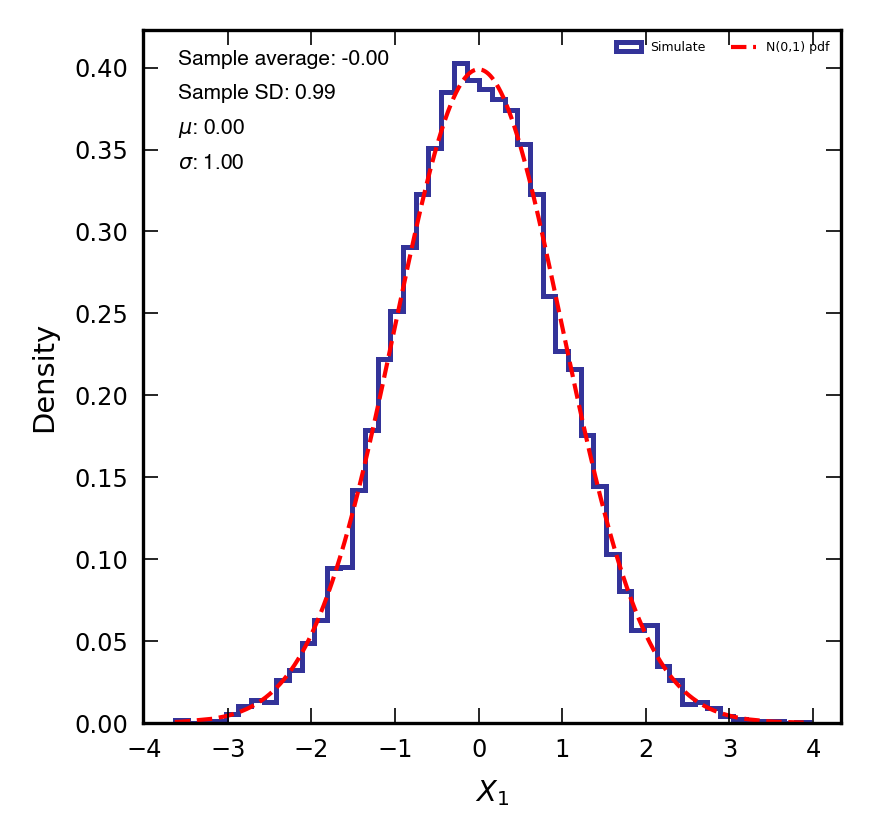

```python
f, ax = plt.subplots(1, 1, figsize=(3, 3), facecolor='white', dpi=300, gridspec_kw={'hspace': 0., 'wspace': 0.})
X1.sort()
ax.hist(X1, density= 1, bins=50, histtype='step',lw= 1.2,color='navy', alpha=0.8, zorder = 0,label = "Simulate")
ax.plot(X1, norm.pdf(X1, 0, 1), 'r--', lw=1, label='N(0,1) pdf', zorder = 1)
ax.text(0.05, 0.95, "Sample average: %.2f"%(np.mean(X1)), size=5, weight = 'bold',style=fig_style, family=fig_family, fontname=fig_typeface, transform=ax.transAxes)
ax.text(0.05, 0.9, "Sample SD: %.2f"%(np.std(X1)), size=5, weight = 'bold',style=fig_style, family=fig_family, fontname=fig_typeface, transform=ax.transAxes)
ax.text(0.05, 0.85, r"$\mu$: %.2f"%(0), size=5, weight = 'bold',style=fig_style, family=fig_family, fontname=fig_typeface, transform=ax.transAxes)
ax.text(0.05, 0.8, r"$\sigma$: %.2f"%(1), size=5, weight = 'bold',style=fig_style, family=fig_family, fontname=fig_typeface, transform=ax.transAxes)
ax.tick_params(axis='both', which='both', labelsize='xx-small', right=True, top=True, direction='in', width=.4)
ax.set_xlabel(r"$X_1$", size='x-small')
ax.set_ylabel("Density", size='x-small')
#         ax.set_xlim(x_range)
#         ax.set_ylim(y_range)
ax.legend(loc = 1 ,fontsize = 3,markerscale = 2,ncol = 3,scatterpoints= 1,frameon = True,framealpha =0.).get_frame().set_linewidth(0.0)
plt.show()
```

## 3c. Draw a sample of size 10,000 from the conditional distribution p($X_1$|$X_2,\; X_3$ ), take $X_2 = X_3 = 1$. Compute the sample mean and sample SD and compare these numbers to the true values. Draw a histogram of the simulated values, along with the true conditional distribution.

The covaraince martix can be written as :
$$\begin{bmatrix} \sigma^2_{X_1} & \rho_{X_1,X_2}\sigma_1 \sigma_2 & \rho_{X_1,X_3}\sigma_1 \sigma_3 \\ \rho_{X_1,X_2}\sigma_1 \sigma_2 & \sigma^2_{X_2} & \rho_{X_2,X_3}\sigma_2 \sigma_3 \\ \rho_{X_1,X_3}\sigma_1 \sigma_3 & \rho_{X_2,X3}\sigma_2 \sigma_3 & \sigma^2_{X_3} \end{bmatrix} = $$ $$\begin{bmatrix} 1^2 & 0.9 \times 1 \times 5 & 0.9 \times 1 \times 10\\ 0.9 \times 1 \times 5 & 5^2 & 0.98 \times 5 \times 10 \\ 0.9 \times 1 \times 10 & 0.98 \times 5 \times 10 & 10^2 \end{bmatrix}$$
E[$X_1$|$X_2 =x_2, X_3 = x_3$] = $\mu_1$ + $\frac{\sigma_1(\sigma_3(x_2 - \mu_2)(\rho_{23}\rho_{13} - \rho_{12}) - \sigma_2(x_3 - \mu_3)(\rho_{13} - \rho_{23}\rho_{12})}{(\rho_{23}^2 - 1)\sigma_2 \sigma_3}$

Var($X_1$|$X_2 =x_2, X_3 = x_3$) = $\frac{\sigma_1^2(\rho_{23}^2 - 2\rho_{23}\rho_{13}\rho_{12} + \rho_{13}^2 + \rho_{12}^2 - 1)}{\rho_{23}^2 -1}$  
Hence, E[$X_1$|$X_2 =1, X_3 = 1$] = 0.1363636363636362  
Var($X_1$|$X_2 = 1, X_3 = 1$) = 0.18181818181818385  
STD($X_1$|$X_2 = 1, X_3 = 1$) = 0.4263

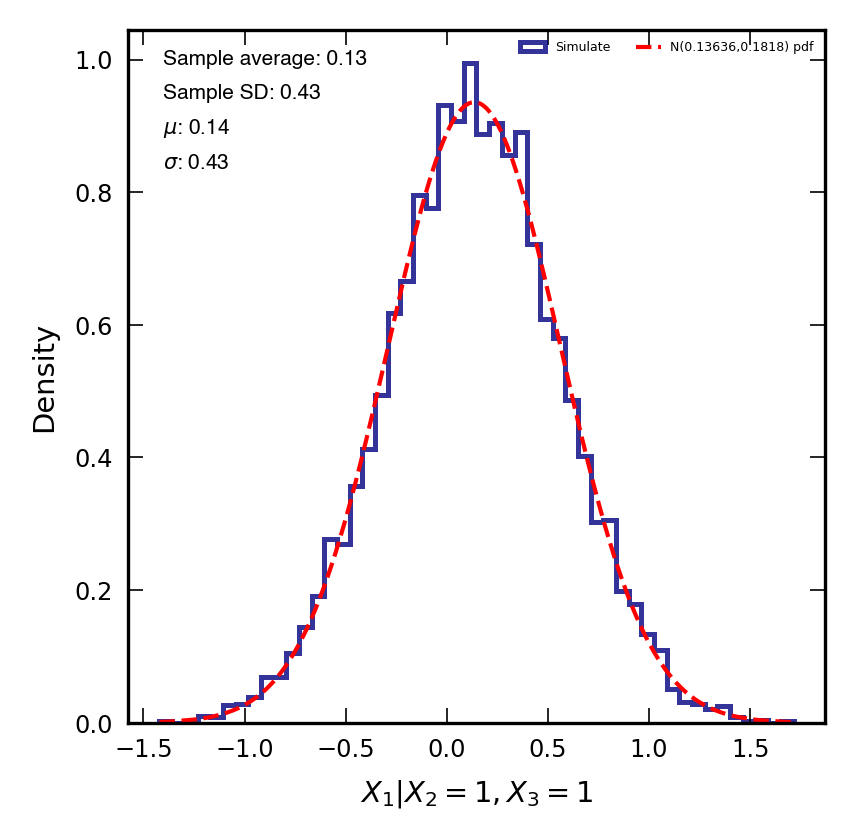

```python
f, ax = plt.subplots(1, 1, figsize=(3, 3), facecolor='white', dpi=300, gridspec_kw={'hspace': 0., 'wspace': 0.})
X1_11 = np.random.normal(0.13636, np.sqrt(0.1818), int(1e4))
X1_11.sort()
ax.hist(X1_11, density= 1, bins=50, histtype='step',lw= 1.2,color='navy', alpha=0.8, zorder = 0,label = "Simulate")
ax.plot(X1_11, norm.pdf(X1_11, 0.13636, np.sqrt(0.1818)), 'r--', lw=1, label=r'N(0.13636,0.1818) pdf', zorder = 1)
ax.text(0.05, 0.95, "Sample average: %.2f"%(np.mean(X1_11)), size=5, weight = 'bold',style=fig_style, family=fig_family, fontname=fig_typeface, transform=ax.transAxes)
ax.text(0.05, 0.9, "Sample SD: %.2f"%(np.std(X1_11)), size=5, weight = 'bold',style=fig_style, family=fig_family, fontname=fig_typeface, transform=ax.transAxes)
ax.text(0.05, 0.85, r"$\mu$: %.2f"%(0.13636), size=5, weight = 'bold',style=fig_style, family=fig_family, fontname=fig_typeface, transform=ax.transAxes)
ax.text(0.05, 0.8, r"$\sigma$: %.2f"%(np.sqrt(0.1818)), size=5, weight = 'bold',style=fig_style, family=fig_family, fontname=fig_typeface, transform=ax.transAxes)
ax.tick_params(axis='both', which='both', labelsize='xx-small', right=True, top=True, direction='in', width=.4)
ax.set_xlabel(r"$X_1|X_2=1,X_3 = 1$", size='x-small')
ax.set_ylabel("Density", size='x-small')
#         ax.set_xlim(x_range)
#         ax.set_ylim(y_range)
ax.legend(loc = 1 ,fontsize = 3,markerscale = 2,ncol = 3,scatterpoints= 1,frameon = True,framealpha =0.).get_frame().set_linewidth(0.0)
plt.show()
```